# Sprawozdanie 1

Łukasz Maczek, Marta Kreis

2025-10-19

# Zadanie 1

Na początku zadania wczytano plik `stroke`, który zawiera dane dotyczące pacjentów, u których miał miejsce udar lub nie. Zbiór składa się z 11 zmiennych, z których zmienne jakościowe zostały zamienione na zmienne binarne:

- Gender (płeć) - zmienna binarna (1 w przypadku gdy mężczyzna)
- Age (wiek) - zmienna liczbowa
- Hypertension (nadciśnienie) - zmienna binarna (1 gdy nadciśnienie występuje)
- Heart_disease (choroba serca) - zmienna binarna (1 gdy choroba serca występuje)
- Ever_married (Czy osoba była kiedyś w związku małżeńskim) - zmienna binarna (1 gdy była)
- Work_type (Prywatna, Rządowa, Samozatrudnienie, Bezrobotny, Dziecko) - podzielone na 5 zmiennych binarnych (1 gdy któraś z opcji)
- Residence_type (Miejsce zamieszkania) - zmienna binarna (1 gdy miejsce zamieszkania w mieście)
- Avg_glucose_level (średni poziom glukozy) - zmienna liczbowa
- Bmi - zmienna liczbowa
- Smoking_status (Kiedyś palił, Nadal pali, Nigdy nie palił, Nieznane) - podzielone na 4 zmienne binarne (1 gdy któraś z opcji)
- Stroke (udar) - zmienna binarna (1 gdy wystąpił udar)

## Potrzebne pakiety

```r
library(class)
library(kknn)
library(mice)
library(recipes)
library(caret)
```

## Wczytanie danych oraz ich obróbka

```r
dane_stroke = read.csv2("stroke.csv", dec = ".")
head(dane_stroke)
```

```
##   gender age hypertension heart_disease ever_married     work_type
## 1   Male  67            0             1          Yes       Private
## 2 Female  61            0             0          Yes Self-employed
## 3   Male  80            0             1          Yes       Private
## 4 Female  49            0             0          Yes       Private
## 5 Female  79            1             0          Yes Self-employed
## 6   Male  81            0             0          Yes       Private
##   Residence_type avg_glucose_level  bmi  smoking_status stroke
## 1          Urban            228.69 36.6 formerly smoked      1
## 2          Rural            202.21   NA    never smoked      1
## 3          Rural            105.92 32.5    never smoked      1
## 4          Urban            171.23 34.4          smokes      1
## 5          Rural            174.12 24.0    never smoked      1
## 6          Urban            186.21 29.0 formerly smoked      1
```

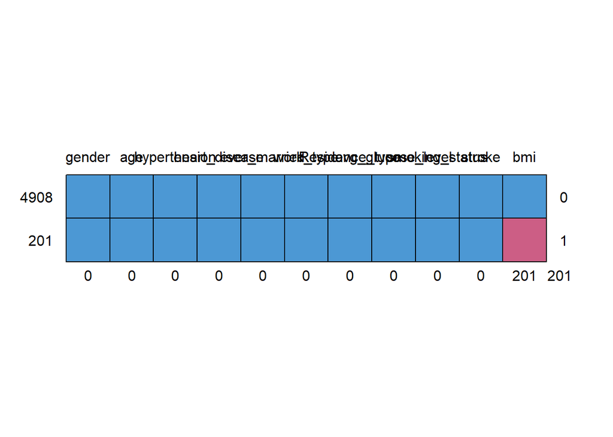

```
##      gender age hypertension heart_disease ever_married work_type
## 4908      1   1            1             1            1         1
## 201       1   1            1             1            1         1
##           0   0            0             0            0         0
##      Residence_type avg_glucose_level smoking_status stroke bmi
## 4908              1                 1              1      1   1   0
## 201               1                 1              1      1   0   1
##                   0                 0              0      0 201 201
```

```r
md.pattern(dane_stroke)
```

```r
dane_stroke = na.omit(dane_stroke)
md.pattern(dane_stroke)
```

```
##  /\     /\
## {  `---'  }
## {  O   O  }
## ==>  V <==  No need for mice. This data set is completely observed.
##  \  \|/  /
##   `-----'
```

[figure not shown]

```
##      gender age hypertension heart_disease ever_married work_type
## 4908      1   1            1             1            1         1
##           0   0            0             0            0         0
##      Residence_type avg_glucose_level bmi smoking_status stroke
## 4908              1                 1   1              1      1 0
##                   0                 0   0              0      0 0
```

```r
dane_stroke$gender = ifelse(dane_stroke$gender=="Male", 1, 0) # Male to 1
dane_stroke$ever_married = ifelse(dane_stroke$ever_married=="Yes", 1, 0)
dane_stroke$Residence_type = ifelse(dane_stroke$Residence_type=="Urban", 1, 0) #Urban to 1

#zamiana zmiennych work_type oraz smoking_status na kilka zmiennych binarnych za pomocą model.matrix()
dane_stroke$work_type = model.matrix(~ dane_stroke$work_type - 1)
dane_stroke$smoking_status = model.matrix(~ dane_stroke$smoking_status - 1)
dane_stroke$stroke = as.factor(dane_stroke$stroke)

#balansowanie zbioru
stroke_0 = dane_stroke[dane_stroke$stroke == 0, ]
stroke_1 = dane_stroke[dane_stroke$stroke == 1, ]

set.seed(416669)
stroke_0_sample = stroke_0[sample(1:nrow(stroke_0), nrow(stroke_1)), ]

dane_stroke_final = rbind(stroke_0_sample, stroke_1)
```